# R Notebook

```r
library(tidyverse)
library(CodeClanData)
library(scales)
col_scheme <- c("#E89FE9", "#50434F", "#B6A7B5", "#F9A472", "#BD7040")
```

Adding appropriate labels Changing the scales and coordinates when appropriate. Applying a unified theme, which is described below: Graphs should have white backgrounds, and use colour sparingly. There should be faint grid lines. Font sizes should be ~12pt although titles should be slightly larger and axis labels can be slightly smaller. All plots should use colours from the following company colour scheme.

```r
homework_theme <- function() {
  theme(
    panel.background = element_rect(fill = "white"),
    panel.border = element_rect(color = "black", size = 0.5, fill = NA),
    panel.grid = element_line(colour = "grey", size = 0.2),
    axis.text = element_text(size = 10),
    axis.title = element_text(size = 14),
    title = element_text(size = 16)
  )
}
```

```r
qb_revenue_breakdown
```

| Product | Year | Revenue |
| --- | --- | --- |
| Trackers | 2019 | 8994 |
| Smart Watches | 2019 | 12003 |
| Accessories | 2019 | 5250 |
| Subscription Services | 2019 | 3750 |
| Trackers | 2018 | 8004 |
| Smart Watches | 2018 | 11000 |
| Accessories | 2018 | 4250 |
| Subscription Services | 2018 | 1005 |

```r
NA
```

# MVP part 1

## Question 1.

Take the data in the dataset qb_revenue_breakdown and make a stacked bar chart showing the sources of revenue across the two years in the dataset.

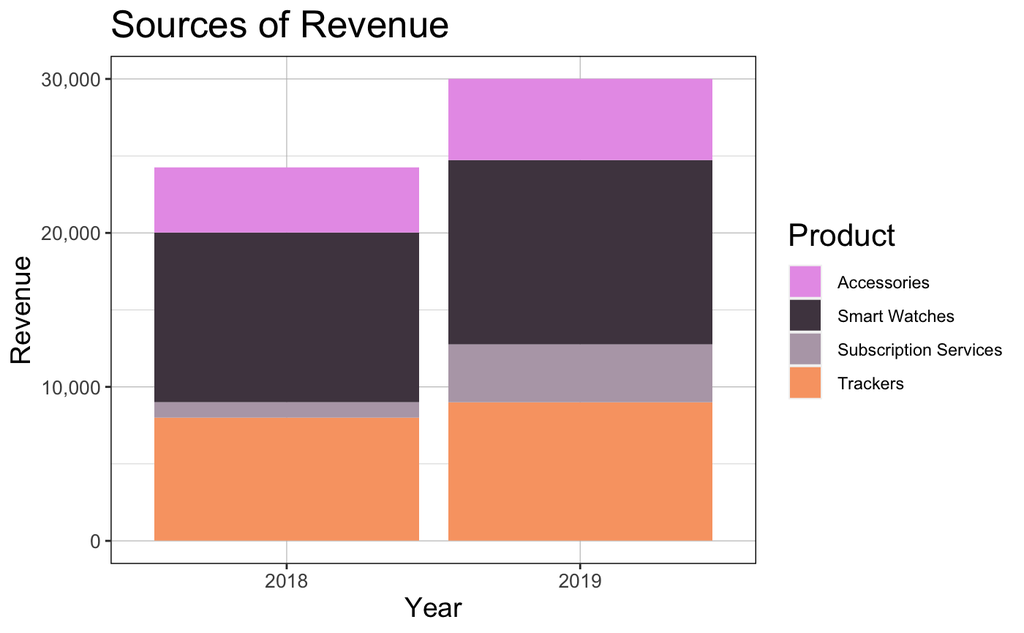

```r
ggplot(qb_revenue_breakdown, aes(x = Year, y = Revenue, fill = Product)) +
  geom_col() +
  scale_y_continuous(labels = comma) +
  ggtitle("Sources of Revenue") +
  scale_fill_manual(values = col_scheme) +
  homework_theme()
```

```r
NA
```

## Question 2.

Make a line chart showing monthly sales of the “flagship product” - the ‘KwikBit Unit 1’ - over the last year. This data is inside qb_monthly_sales, but you will need to use filter() or subset() (base R).

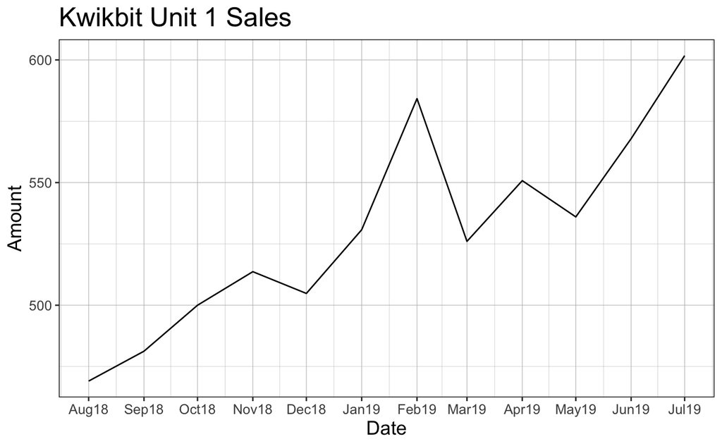

```r
qb_monthly_sales %>%
  filter(Cashflow == "Kwikbit Unit 1 Sales") %>%
  ggplot( aes(x = Date, y = Amount)) +
  geom_line() +
  labs ( title = "Kwikbit Unit 1 Sales") +
  scale_x_date(date_breaks = "1 month", date_labels = "%b%y") +
  homework_theme()
```

Question 3. Make a line chart showing monthly revenue and costs over the last year. This data is also in qb_monthly_sales.

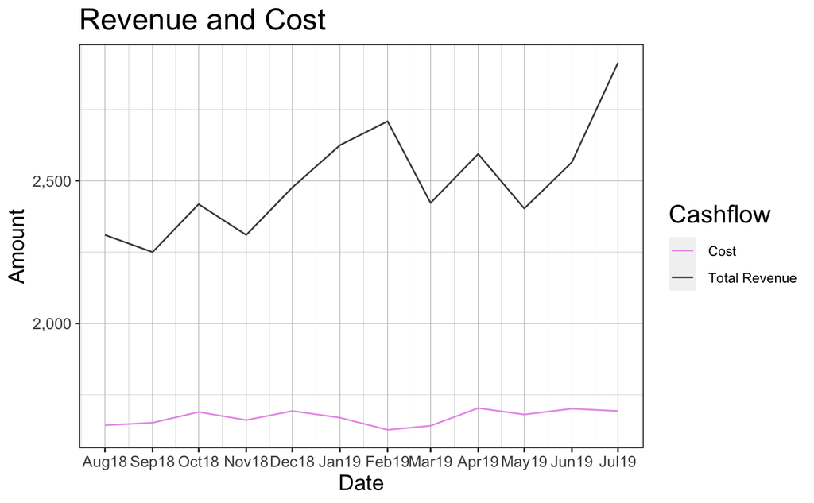

```r
qb_monthly_sales %>%
  filter ( Cashflow != "Kwikbit Unit 1 Sales") %>%
  ggplot(aes(x = Date, y = Amount, colour = Cashflow)) +
  geom_line() +
  scale_x_date(date_breaks = "1 month", date_labels = "%b%y") +
  scale_colour_manual(values = col_scheme) +
  scale_y_continuous(labels = comma) +
  homework_theme() +
  ggtitle("Revenue and Cost")
```

Question 4. Show annual sales of personal fitness trackers over the last 5 years broken down by company as a ribbon plot (use geom_area). This data is in qb_competitors.

```r
qb_competitors
```

| Company | Year | Revenue |
| --- | --- | --- |
| Competitor 1 | 2019 | 2216000 |
| Competitor 2 | 2019 | 1760000 |
| Competitor 3 | 2019 | 1455000 |
| Competitor 4 | 2019 | 1229000 |
| Competitor 1 | 2018 | 2144400 |
| Competitor 2 | 2018 | 1440000 |
| Competitor 3 | 2018 | 1555000 |
| Competitor 4 | 2018 | 987000 |
| Competitor 1 | 2017 | 1750000 |
| Competitor 2 | 2017 | 987000 |

[output cut: 10 more lines]

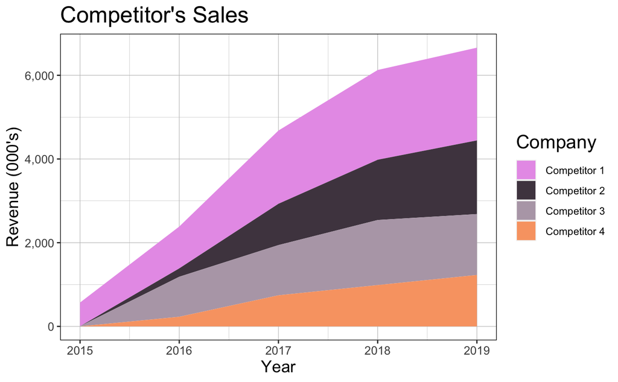

```r
qb_competitors %>%
  mutate(revenue_thousands = Revenue / 1000) %>%
ggplot(aes( x = Year, y = revenue_thousands, fill = Company)) +
  geom_area() +
  ylab ("Revenue (000's)") +
  labs (title = "Competitor's Sales")+
  scale_y_continuous(labels = comma) +
  scale_fill_manual(values = col_scheme) +
  homework_theme()
```

Question 5. Now show the sales from the four competitors as a line graph. Include an extra layer that shows the data points used to make the lines.

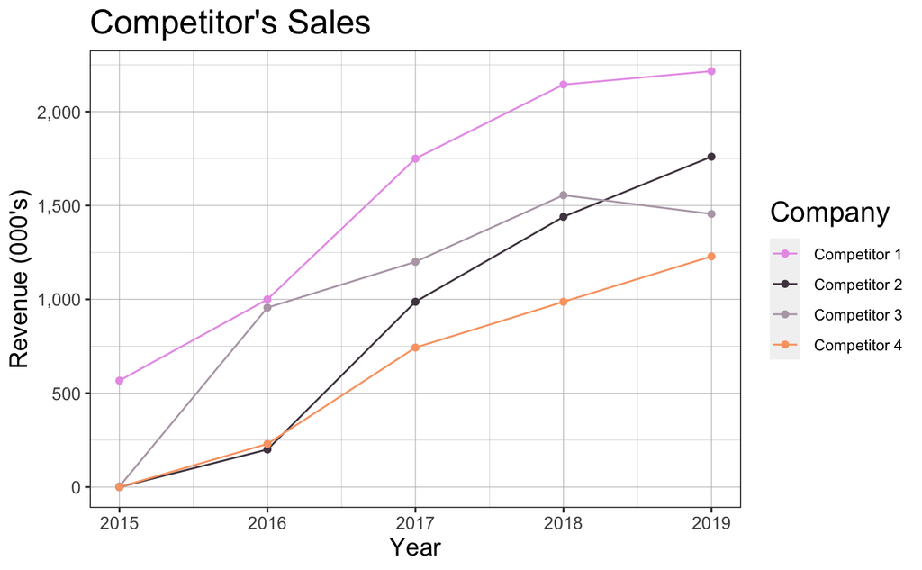

```r
qb_competitors %>%
  mutate(revenue_thousands = Revenue / 1000) %>%
ggplot(aes( x = Year, y = revenue_thousands, colour = Company)) +
  geom_line() +
  geom_point() +
  ylab ("Revenue (000's)") +
  labs (title = "Competitor's Sales") +
  scale_y_continuous(labels = comma) +
  scale_colour_manual(values = col_scheme) +
  homework_theme()
```

```r
NA
```

Question 6. Now the company wants to compare the number of steps that their device counts vs. their competitors. Make a line graph of the number of steps throughout time, and use faceting to compare between companies and people. The data for this is in qb_device_data.

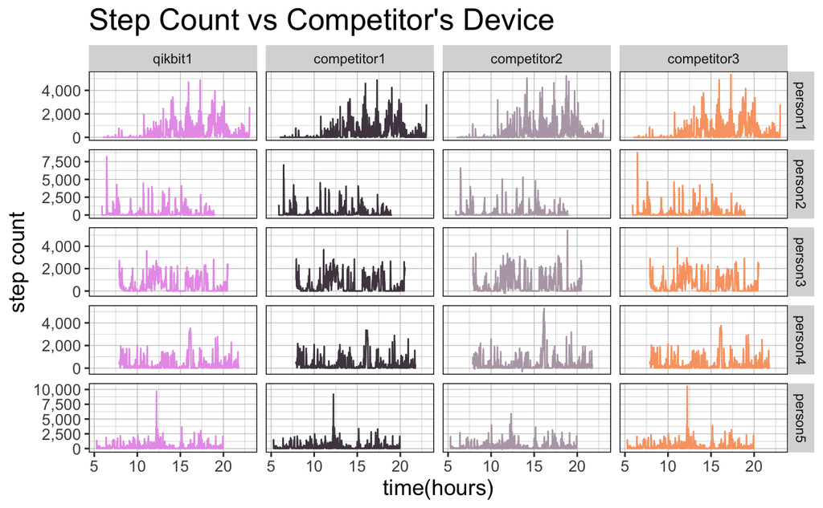

```r
qb_device_data %>%
  mutate(hours_total = mins / 60 + hours) %>%
  #mutate(`hrs:mins` = paste0(hours, ":", mins)) %>%#,
         #`hrs:mins` = strptime(`hrs:mins`, format = "%H:%M"))
  ggplot(aes(x = hours_total, y = counts, colour = device)) +
  geom_line(show.legend = F) +
  facet_grid(id ~ device, scales = "free_y") +
  xlab("time(hours)") +
  ylab("step count") +
  scale_y_continuous(labels = comma) +
  ggtitle("Step Count vs Competitor's Device")+
  scale_colour_manual(values = col_scheme) +
  homework_theme()
```